# DSI - Assignment 4 - Q3

Dipin P Joseph

The dataset contains 10000 observations consists of 3 numeric variables along with timestamps. The given data may not be following a normal distribution. Hence, as a better approach, the observations are grouped by dates which are extracted from ‘Timestamp’ since means of consecutive observations tend to be normally distributed so that control charts will avoid false positives. The current grouped, near-normal data is best described by ‘xbar’ and ‘s’ control charts (for average measurements).

```r
library(qicharts2)
library(readr)
library(dplyr)
df <- read.csv("monitor.csv")
#den <- density(df$Prediction)
#plot(den)
df_agg <- df %>% group_by(as.Date(df$Timestamp))
colnames(df_agg)[5]<- "Date"
summary(df_agg)
```

```
##                Timestamp    ProcessMemory     Prediction    PredictionTimeMS
##  2019-01-30 00:21:30:   2   Min.   :10.14   Min.   :39.03   Min.   : 90.06
##  2019-02-04 23:38:56:   2   1st Qu.:11.75   1st Qu.:47.61   1st Qu.:300.44
##  2019-02-12 03:42:56:   2   Median :12.08   Median :55.08   Median :349.40
##  2019-02-16 17:34:44:   2   Mean   :12.08   Mean   :55.05   Mean   :349.27
##  2019-02-19 03:39:05:   2   3rd Qu.:12.42   3rd Qu.:62.47   3rd Qu.:397.19
##  2019-02-22 09:12:21:   2   Max.   :14.28   Max.   :71.00   Max.   :680.30
##  (Other)            :9988
##       Date
##  Min.   :2019-01-01
##  1st Qu.:2019-01-30
##  Median :2019-02-19
##  Mean   :2019-02-18
##  3rd Qu.:2019-03-12
##  Max.   :2019-04-01
##
```

Total observations in each Date group,

```r
df_agg %>% group_by(Date) %>% count()
```

```
## # A tibble: 91 x 2
## # Groups:   Date [91]
##    Date           n
##    <date>     <int>
##  1 2019-01-01    25
##  2 2019-01-02    85
##  3 2019-01-03    74
##  4 2019-01-04    95
##  5 2019-01-05   107
##  6 2019-01-06    79
##  7 2019-01-07    88
##  8 2019-01-08    92
##  9 2019-01-09    83
## 10 2019-01-10   110
## # … with 81 more rows
```

## a) Is the memory usage of the server in control?

The data of ‘ProcessMemory’(the allocated memory (MB) of the relevant server process) for the first 20(freeze parameter) days were used for learning and defining control limits for later data. The mean and standard deviation is calculated till freeze and after the freeze to obtain the shift of distribution and found only negligible step difference.

```r
# Mean
#First 20 day
mean(df_agg[0:20,]$ProcessMemory)
```

```
## [1] 11.9821
```

```r
sqrt(var(df_agg[0:20,]$ProcessMemory))
```

```
## [1] 0.4877345
```

```r
# SD
# After 20 days
mean(df_agg[21:10000,]$ProcessMemory)
```

```
## [1] 12.085
```

```r
sqrt(var(df_agg[21:10000,]$ProcessMemory))
```

```
## [1] 0.5050161
```

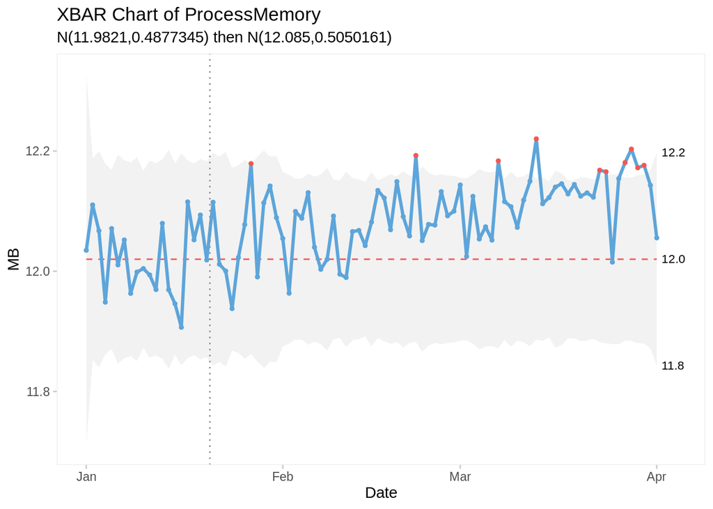

```r
P<-qicharts2::qic(ProcessMemory,
               x     = Date,
               data  = df_agg,
               chart = 'xbar',
               ylab  = 'MB',
               xlab  = 'Date',
               freeze = 20,
               subtitle = "N(11.9821,0.4877345) then N(12.085,0.5050161)")
P
```

```r
summary(P)
```

```
##   facet1 facet2 part n.obs n.useful longest.run longest.run.max n.crossings
## 1      1      1    1    91       91          41              10          22
##   n.crossings.min runs.signal     aLCL       CL     aUCL sigma.signal
## 1              37           1 11.86963 12.01999 12.17036           10
```

The control charts show a gradual upward movement from the mean line on considered data. It is justified by the param ‘longest.runs - 41’. From mid-February, for 41 consecutive days, the memory usage hasn’t lowered to mean value, hence the system will move out of control gradually. Also, in chart 10 red points (sigma.signal-10) crossing upper limit(runs.signal - 1 denotes breach), longest.run -41 > longest.run.max- 10 and ‘n.crossings - 22’ is less than ‘n.crossings.min - 37’ so the range is deviating from mean showing the need for a thorough examination of the system.

Plotting ‘s’ chart to check for Process memory’s variability.

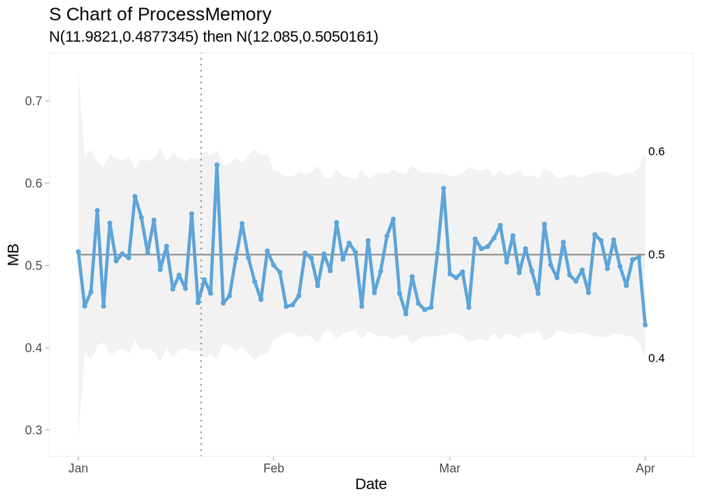

```r
q<-qicharts2::qic(ProcessMemory,
    x = Date,
    data = df_agg,
    chart = 's',
    ylab = 'MB',
    xlab = 'Date',
    freeze = 20,
    subtitle = "N(11.9821,0.4877345) then N(12.085,0.5050161)")
q
```

```r
summary(q)
```

```
##   facet1 facet2 part n.obs n.useful longest.run longest.run.max n.crossings
## 1      1      1    1    91       91           6              10          47
##   n.crossings.min runs.signal     aLCL        CL      aUCL sigma.signal
## 1              37           0 0.406453 0.5131864 0.6199198            0
```

The variability of ProcessMemory is found within the limits(along with few upper and lower spikes). Hence, in terms of variablitiy alone, the ProcessMemory is in control(runs.signal-0 denotes no breach, longest.run-6 < longest.run.max-10 and n.crossings-47 > n.crossings.min-37).

Since Xbar chart is out of control the overall conclusion is that the ‘ProcessMemory’ is out of control.

## b) Is the prediction time of the model in control?

A similar approach is taken to check control of ‘PredictionTimeMS’(the duration of the prediction task in milliseconds). Data of the first 20 days of January is taken for calculating control limits. From the mean and standard deviation of two sets of ‘PredictionTimeMS’ small step change is observed.

```r
#First 20 days
mean(df_agg[0:20,]$PredictionTimeMS)
```

```
## [1] 334.1878
```

```r
sqrt(var(df_agg[0:20,]$PredictionTimeMS))
```

```
## [1] 83.06285
```

```r
#After 20 days
mean(df_agg[21:10000,]$PredictionTimeMS)
```

```
## [1] 349.2994
```

```r
sqrt(var(df_agg[21:10000,]$PredictionTimeMS))
```

```
## [1] 72.26461
```

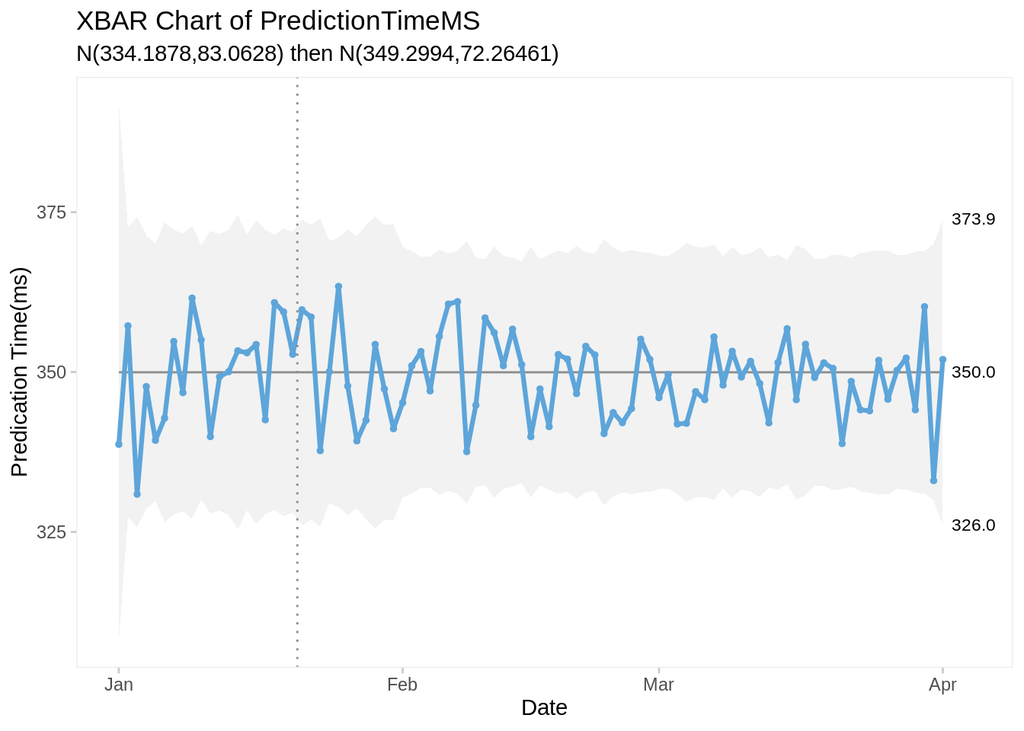

```r
p1<-qicharts2::qic(PredictionTimeMS,
    x     = Date,
    data  = df_agg,
    chart = 'xbar',
    ylab  = 'Predication Time(ms)',
    xlab  = 'Date',
    freeze = 20,
    subtitle = "N(334.1878,83.0628) then N(349.2994,72.26461)")
p1
```

```r
summary(p1)
```

```
##   facet1 facet2 part n.obs n.useful longest.run longest.run.max n.crossings
## 1      1      1    1    91       91           6              10          45
##   n.crossings.min runs.signal     aLCL      CL     aUCL sigma.signal
## 1              37           0 329.6677 349.967 370.2662            0
```

From control charts and summary, it can be said that mean of ‘PredictionTimeMS’ is under control since longest.run-6 < longest.run.max-10, n.crossings-45>n.crossings.min-37 and runs.signal-0 and sigma.signal-0 indicates no breaches.

Plotting ‘s’ chart to check for Prediction Time variability.

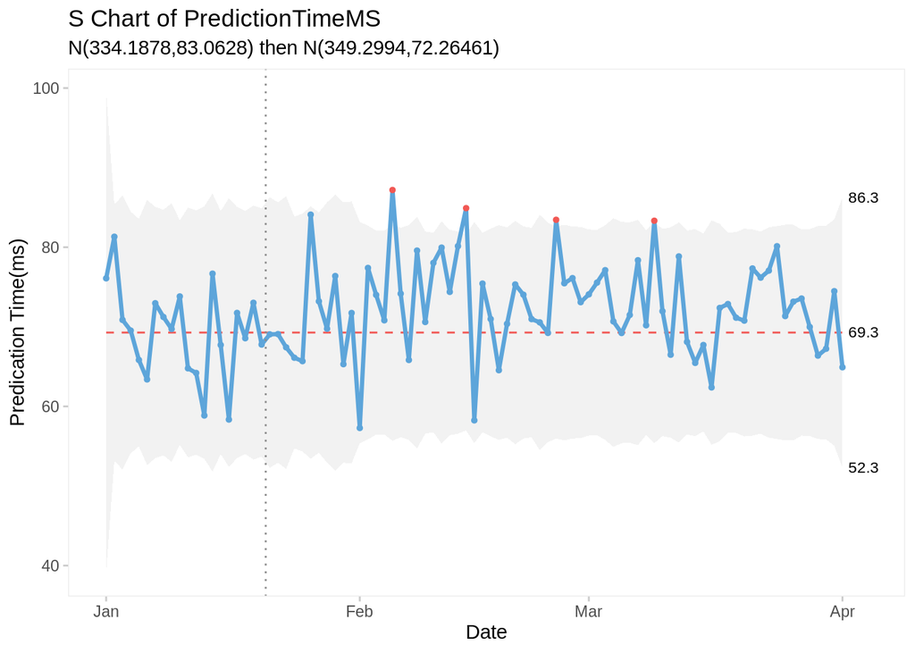

```r
q1<-qicharts2::qic(PredictionTimeMS,
    x     = Date,
    data  = df_agg,
    chart = 's',
    ylab  = 'Predication Time(ms)',
    xlab  = 'Date',
    freeze = 20,
    subtitle = "N(334.1878,83.0628) then N(349.2994,72.26461)")
q1
```

```r
summary(q1)
```

```
##   facet1 facet2 part n.obs n.useful longest.run longest.run.max n.crossings
## 1      1      1    1    91       91          12              10          31
##   n.crossings.min runs.signal    aLCL       CL     aUCL sigma.signal
## 1              37           1 54.8714 69.28048 83.68956            4
```

From control chart, Prediction Time went out of control at 4 instances(4 red points above upper limit, sigma.signal-4) between February and April. It’s justified with summary parameters - longest.run-12>longest.run.max-10, n.crossings-31<n.crossings.min-37 and runs.signal-1(breach).

So, it is concluded based on overall Predication Time, the system will be out of control when high variability occurs.

## c) Is the stream of predictions in control?

Similar approach is taken to check control of ‘Prediction’(the value predicted by the model). Data of the first 20 days of January is taken for calculating control limits. From mean and standard deviation of two sets of ‘Prediction’ negligible step change is observed.

```r
# First 20 days
mean(df_agg[0:20,]$Prediction)
```

```
## [1] 52.84359
```

```r
sqrt(var(df_agg[0:20,]$Prediction))
```

```
## [1] 9.24843
```

```r
# After 20 days
mean(df_agg[21:10000,]$Prediction)
```

```
## [1] 55.05381
```

```r
sqrt(var(df_agg[21:10000,]$Prediction))
```

```
## [1] 8.609205
```

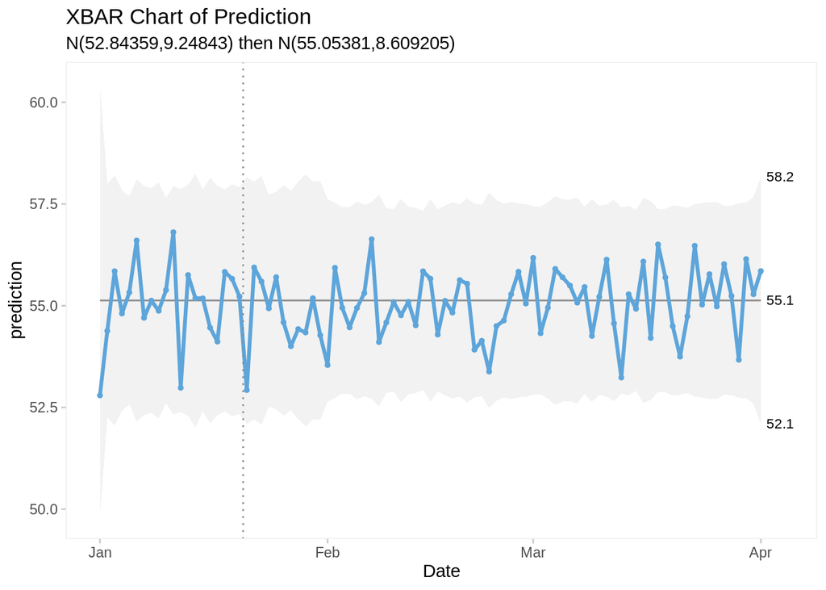

```r
p2<-qicharts2::qic(Prediction,
    x     = Date,
    data  = df_agg,
    chart = 'xbar',
    ylab  = 'prediction',
    xlab  = 'Date',
    freeze = 20,
    subtitle = "N(52.84359,9.24843) then N(55.05381,8.609205)")
p2
```

```r
summary(p2)
```

```
##   facet1 facet2 part n.obs n.useful longest.run longest.run.max n.crossings
## 1      1      1    1    91       91           6              10          47
##   n.crossings.min runs.signal     aLCL       CL     aUCL sigma.signal
## 1              37           0 52.55403 55.12889 57.70376            0
```

Here, it seems we are looking into outliers and spread of predicted values. From the Xbar chart and summary, it seems the system is in control. There is no breaches or limit crossing (runs.signal-0, sigma.signal-0) or any long run or crossing violations is observed(longest.run-6<longest.run.max-10 and n.crossings.min-37<n.crossings-47).

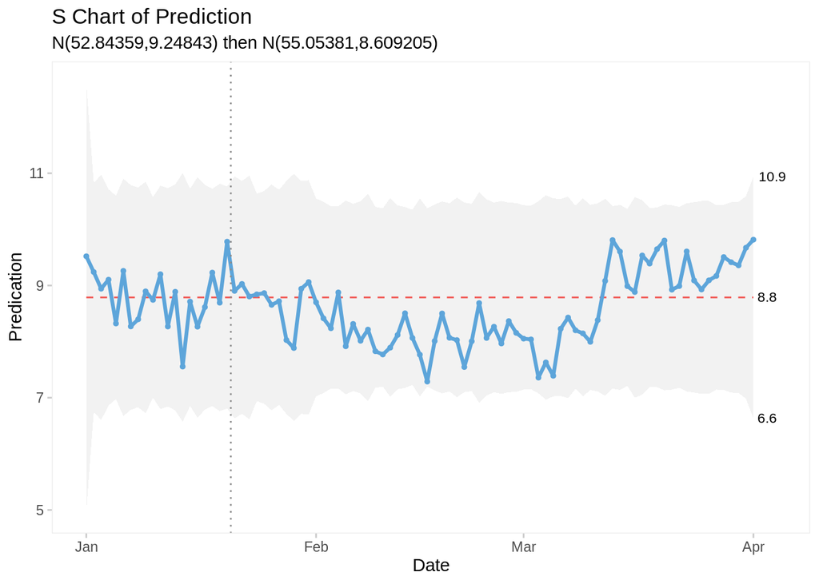

```r
q2<-qicharts2::qic(Prediction,
    x     = Date,
    data  = df_agg,
    chart = 's',
    ylab  = 'Predication',
    xlab  = 'Date',
    freeze = 20,
    subtitle = "N(52.84359,9.24843) then N(55.05381,8.609205)")
q2
```

```r
summary(q2)
```

```
##   facet1 facet2 part n.obs n.useful longest.run longest.run.max n.crossings
## 1      1      1    1    91       91          35              10          18
##   n.crossings.min runs.signal     aLCL       CL     aUCL sigma.signal
## 1              37           1 6.960172 8.787894 10.61562            0
```

The variability of prediction stream seems to be out of control because of long runs in upper(Mid March - April) and lower(February - Mid March) regions (longest.run-35>longest.run.max-10 and runs.signal-1 shows breaches).

So, in conclusion, the stream of predicted values is said to be out of control.